# Membrane fusion: a fundamental process

## Proposal for iterative searching of fusogens

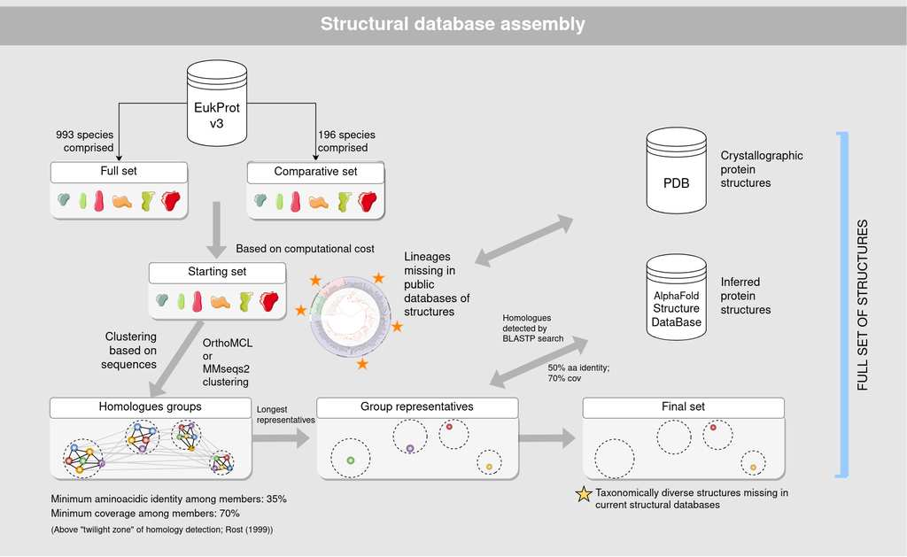

Structural database assembly to obtain a phylogenetically diverse set of eukaryotic protein structures. Icons taken from bioicons (www.bioicons.com).

[figure not shown]

Iterative procedure proposed to detect remote homologues for fusexins and fusogenic DLPs employing structural information. Icons taken from bioicons (www.bioicons.com).

# Advances in the study of dynamin-like proteins

This interesting family posses members that are known to be mitochondrial fusogens in eukaryotes. Bacterial members have been discovered in the last decades, but their functions remain in many cases unknown (e.g., it has been postulated that might have a role in membrane remodelling, or in fusing lamellar structures in Cyanobacteria).

# Relevant works

- [*Arabidopsis* HAP2/GCS1 is a gamete fusion protein homologous to somatic and viral fusogens](https://www.ncbi.nlm.nih.gov/pmc/articles/PMC5350521/pdf/JCB_201610093.pdf)
- [The ancient gamete fusogen HAP2 is a eukaryotic class II fusion protein](https://www.cell.com/action/showPdf?pii=S0092-8674%2817%2930109-5)
- [Structure-function studies link class II virus fusogens with the ancestral gamete fusion protein HAP2](https://www.cell.com/action/showPdf?pii=S0960-9822%2817%2930084-2)
- What came first, the virus or the egg?
- [HAP2/GCS1: Mounting evidence of our true biological EVE?](https://journals.plos.org/plosbiology/article/file?id=10.1371/journal.pbio.3000007&type=printable)
- [**Discovery of archaeal fusexins homologous to eukaryotic HAP2/GCS1 gamete fusion proteins**](https://www.nature.com/articles/s41467-022-31564-1)

# *Fusexinas* in the press